## Week 4 HW

**1) FCB Exercise 7.3** Australian crab data: The files `bluecrab.dat` and `orangecrab.dat` contain measurements of body depth ($Y_1$) and rear width ($Y_2$), in millimeters, made on 50 male crabs from each of two species, blue and orange. We will model these data using a bivariate normal distribution.

```r
set.seed(59)
bluecrab = as.matrix(read.table(url("http://www2.stat.duke.edu/~pdh10/FCBS/Exercises/bluecrab.dat")))
orangecrab = as.matrix(read.table(url("http://www2.stat.duke.edu/~pdh10/FCBS/Exercises/orangecrab.dat")))
head(bluecrab); head(orangecrab)
```

```
##       V1  V2
## [1,] 6.7 7.0
## [2,] 7.7 7.4
## [3,] 7.8 7.7
## [4,] 7.9 8.2
## [5,] 8.0 8.2
## [6,] 9.0 9.8
```

```
##       V1   V2
## [1,] 6.9  7.4
## [2,] 8.2  9.0
## [3,] 8.6  9.2
## [4,] 9.0 10.1
## [5,] 9.4 10.8
## [6,] 9.4 11.2
```

1. For each of the two species, obtain posterior distributions of the population mean $\theta$ and covariance matrix $\Sigma$ as follows: Using the semiconjugate prior distributions for $\theta$ and $\Sigma$, set $\mu_0$ equal to the sample mean of the data, $\Lambda$ and $S_0$ equal to the sample covariance matrix and $\nu_0 = 4$. Obtain 10,000 posterior samples of $\theta$ and $\Sigma$. Note that this “prior” distribution loosely centers the parameters around empirical estimates based on the observed data (and is very similar to the unit information prior described in the previous exercise). It cannot be considered as our true prior distribution, as it was derived from the observed data. However, it can be roughly considered as the prior distribution of someone with weak but unbiased information.

```r
# blue crab
n = nrow(bluecrab)
ybar = colMeans(bluecrab)
Mu0 = c(ybar)
Sigma = cov(bluecrab)
S0 = Lambda0 = Sigma
nu0 = 4

# Gibbs Sampler
inv = solve
S = 10000
MU = matrix(NA, nrow=S, ncol=2)
SIGMA = matrix(NA, nrow=S, ncol=4)

for(s in 1:S){
  # update MU
  Lambdan = inv(inv(Lambda0) + n*inv(Sigma))
  Mun = Lambdan %*% (inv(Lambda0) %*% Mu0 + n*inv(Sigma) %*% ybar)
  Mu = MASS::mvrnorm(n=1, Mun, Lambdan)

  # update Sigma
  Sn = S0 + (t(bluecrab) - c(Mu)) %*% t(t(bluecrab) - c(Mu))
  # notation -> Sn = S0 = Smu
  # Smu = sum(yi-mu)(y-mu)T
  Sigma = inv(rWishart(1, nu0+n, inv(Sn))[,,1])

  MU[s,] = Mu
  SIGMA[s,] = c(Sigma)
}

# orange crab
n = nrow(orangecrab)
ybar = colMeans(orangecrab)
Mu0 = c(ybar)
Sigma = cov(orangecrab)
S0 = Lambda0 = Sigma
nu0 = 4

# Gibbs Sampler
inv=solve
S = 10000
MU1 = matrix(NA, nrow=S, ncol=2)
SIGMA1 = matrix(NA, nrow=S, ncol=4)

for(s in 1:S){
  # update MU
  Lambdan = inv(inv(Lambda0) + n*inv(Sigma))
  Mun = Lambdan %*% (inv(Lambda0) %*% Mu0 + n*inv(Sigma) %*% ybar)
  Mu = MASS::mvrnorm(n=1, Mun, Lambdan)

  # update Sigma
  Sn = S0 + (t(orangecrab) - c(Mu)) %*% t(t(orangecrab) - c(Mu))
  # notation -> Sn = S0 = Smu
  # Smu = sum(yi-mu)(y-mu)T
  Sigma = inv(rWishart(1, nu0+n, inv(Sn))[,,1])

  MU1[s,] = Mu
  SIGMA1[s,] = c(Sigma)
}
```

2. Plot values of $\theta = (\theta_1, \theta_2)'$ for each group and compare. Describe any size differences between the two groups.

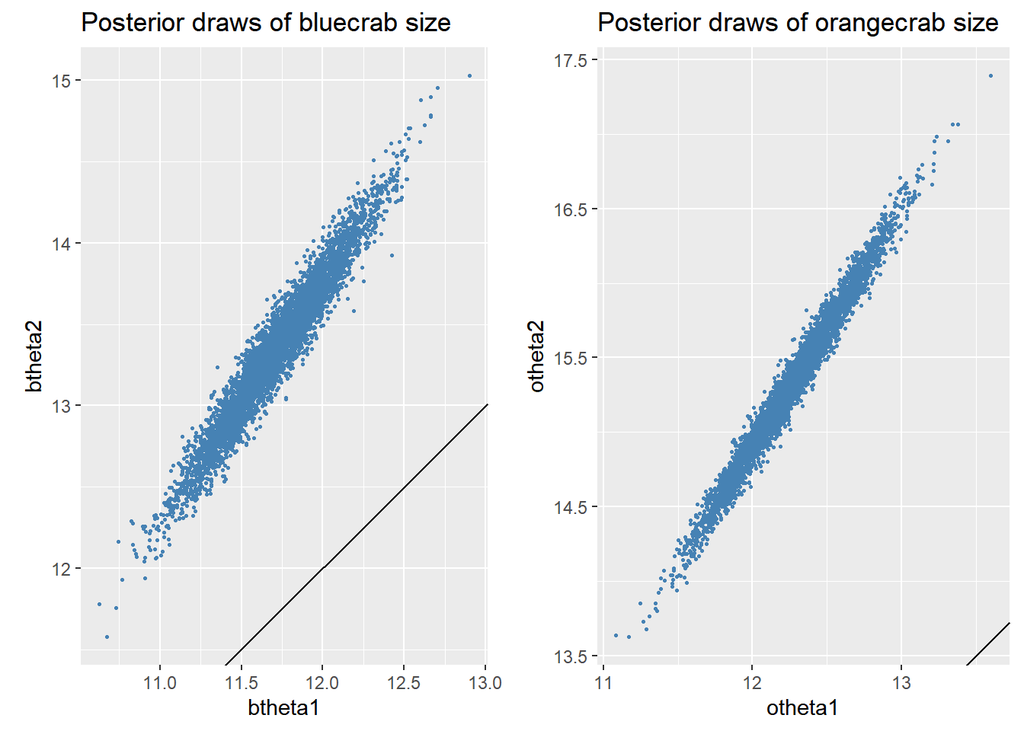

```r
disp = tail(1:S, S/2)

title1 = "Posterior draws of bluecrab size"
p1 = data.frame(btheta1=MU[disp, 1], btheta2=MU[disp,2]) %>%
  ggplot(aes(x=btheta1, y=btheta2)) +
  geom_point(size=0.5, color="steelblue") +
  geom_abline(slope=1, intercept=0) +
  coord_fixed(ratio=1) +
  labs(title=title1)

title2 = "Posterior draws of orangecrab size"
p2 = data.frame(otheta1=MU1[disp,1], otheta2=MU1[disp, 2]) %>%
  ggplot(aes(x=otheta1, y=otheta2)) +
  geom_point(size=0.5, color="steelblue") +
  geom_abline(sloe=1, intercept=0)+
  coord_fixed(ratio=1)+
  labs(title=title2)

ggarrange(p1, p2)
```

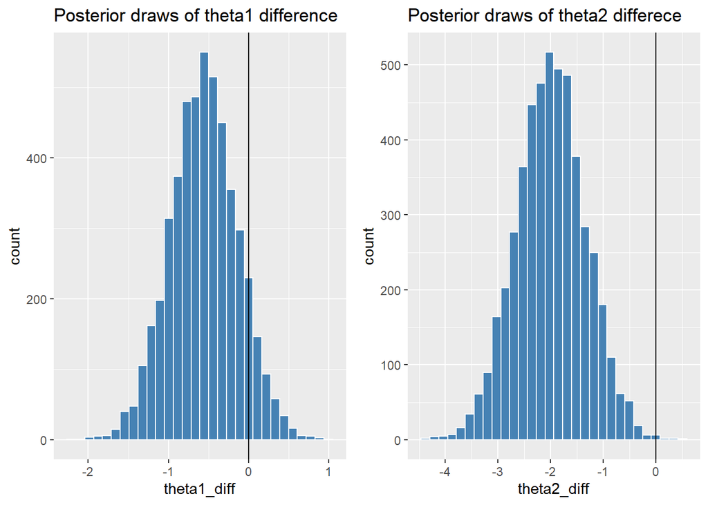

```r
title3 = "Posterior draws of theta1 difference"
theta1_diff = MU[disp, 1] - MU1[disp, 1]
p3 = data.frame(theta1_diff=theta1_diff) %>% ggplot(aes(x=theta1_diff)) +
  geom_histogram(color="white", fill="steelblue", bins=30) +
  geom_vline(xintercept=0) +
  labs(title=title3)

title4 = "Posterior draws of theta2 differece"
theta2_diff = MU[disp, 2] - MU1[disp, 2]
p4 = data.frame(theta2_diff=theta2_diff) %>%
  ggplot(aes(x=theta2_diff)) +
  geom_histogram(color="white", fill="steelblue", bins=30) +
  geom_vline(xintercept=0) +
  labs(title=title4)

ggarrange(p3, p4)
```

```r
mean(MU[disp, 1] > MU1[disp, 1]); mean(MU[disp, 2] > MU1[disp, 2])
```

```
## [1] 0.0956
```

```
## [1] 0.0018
```

3. From each covariance matrix obtained from the Gibbs sampler, obtain the corresponding correlation coefficient. From these values, plot posterior densities of the correlations $\rho_{blue}$ and $\rho_{orange}$ for the two groups. Evaluate differences between the two species by comparing these posterior distributions. In particular, obtain an approximation to $Pr(\rho_{blue} < \rho_{orange}|y_{blue}, y_{orange})$. What do the results suggest about differences between the two populations?

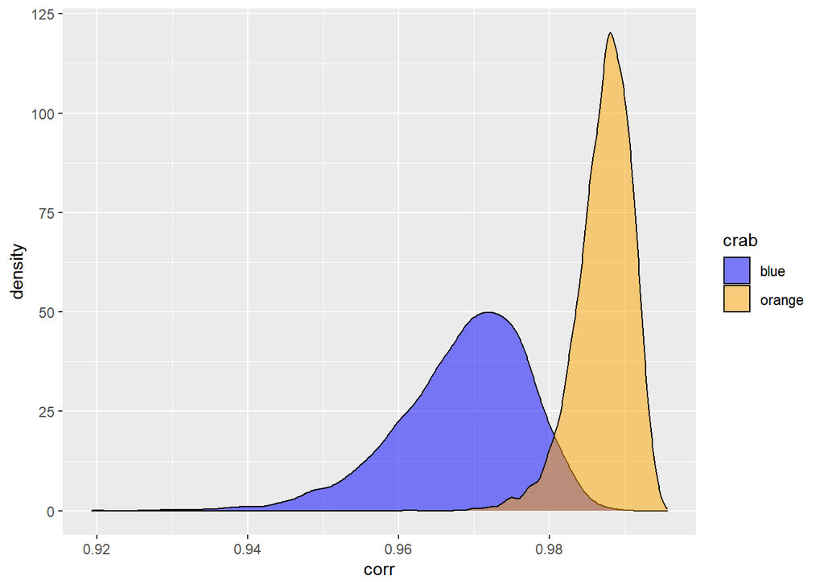

```r
bcorr = apply(SIGMA, MARGIN=1, FUN=function(SIGMA){
  SIGMA[2] / sqrt(SIGMA[1]*SIGMA[4])
})

ocorr = apply(SIGMA1, MARGIN=1, FUN=function(SIGMA){
  SIGMA[2] / sqrt(SIGMA[1]*SIGMA[4])
})

p5 = data.frame(crab=c(rep('blue', length(bcorr)/2), rep('orange', length(ocorr)/2)),
                corr=c(bcorr[disp], ocorr[disp])) %>% ggplot(aes(x=corr, fill=crab)) +
  geom_density(alpha=0.5) +
  scale_fill_manual(values=c('blue', 'orange'))

ggarrange(p5)
```

```r
mean(bcorr < ocorr)
```

```
## [1] 0.9892
```